# Milestone 2 Final Report

## Summary

In this project, we build a predictive model to help new AirBnB hosts set the nightly price of their Vancouver AirBnB. Our predictive model predicts the market price of an AirBnb given the property, host and booking characteristics which we believe is given the the optimal price for both the host and AirBnB guests.

At this stage, we have trained a variety of machine learning models based on property-, host- and book-related characteristics of existing Vancouver AirBnBs. Examples of characteristics include property type, neighborhood, the number of people who can be accommodated, the ability to instant book the property, the booking’s cancellation policy and the responsiveness of the host.

Surprisingly, our linear regression predictor exceeded the performance of more complex machine learning models that were evaluated (e.g., random forest regressor). This model, however, tends to consistently overestimate the price of AirBnB’s below $200/night and underestimate the price of AirBnB’s above $300/night. Further work should involve feature engineering to model interactions between features (e.g., neighborhood and property type) as well as fitting more complex linear models (e.g., that better model pricing behaviour above $300/night).

## Introduction

Becoming an AirBnB host is becoming a popular way to allow property owners to run a small business that can supplement their income and help with mortgage payments in an expensive housing market like Vancouver. One of the key decisions that an AirBnB host has to make is setting the price for the nightly rate of their property.

The AirBnB booking process is like any effective marketplace. Hosts need to set a competitive and fair rate for the use of their property. Guests will compare the quality of the property and the overall booking experience as well as the price against alternatives. A tool that predicts the market price of a property that a host intends to list will inform a host’s pricing decision.

## Methods

### Dataset and Source

We have chosen a dataset that outlines Vancouver AirBnB listings. The dataset can be found [here](http://insideairbnb.com/get-the-data.html) under the Vancouver, British Columbia section. A direct link to download the dataset is [here](http://data.insideairbnb.com/canada/bc/vancouver/2019-11-09/data/listings.csv.gz). This data was compiled November 9 2019.

There are 6181 AirBnB listings in this dataset.

### Analysis

Our research question requires us to build a model that predicts a continuous variable (price) based on property-, host- and booking-related characteristics which a combination of categorical and continuous variables. Types of models that would be appropriate for this task include linear regression, KNN regressor, SVM regressor, and random forest regressor.

In this project, we want to identify a model that is, relatively speaking, more accurate, less computationally intensive and easily interpretable. Accuracy, especially for a range of property types, is important so that hosts can rely on this model. Less computationally intensive models will also be favoured so that the model can be updated frequently based on changing AirBnB data. Being able to interpret the model parameters would be helpful since it would be helpful for hosts to be able to understand how the market price of their property would change if they changed features that were within their control (e.g., relax the cancellation policy).

Our methodology evaluates the models suggested above for accuracy, computational intensity and interpretability. We will train 4 models (linear regression, KNN regressor, SVM regressor, and random forest regressor) to shortlist 2-3 that we will tune hyperparameters for. The tuned models will be compared against each other before deciding on one final model.

The R and Python programming languages (R Core Team 2019; Van Rossum and Drake 2009) and the following R and Python packages were used to perform the analysis: pandas (McKinney and others 2010), numpy (Oliphant 2006), requests (Chandra and Varanasi 2015), os (Van Rossum and Drake 2009), docopt (de Jonge 2018), tidyverse (Wickham 2017), testthat (Wickham 2011), checkmate (Lang 2017), altair (Lyttle 2018), and sklearn (Pedregosa et al. 2011).

## Results and Discussion

### Exploring our data

To begin our analysis, we wanted to understand a) the range and distribution of prices represented in our dataset and b) potential issues with sparse data for neighborhood and property type categorical variables.

#### Distribution of AirBnB nightly prices in our dataset

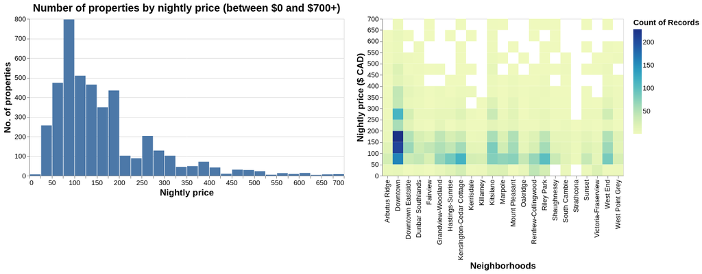

Figure 1: Number of properties by nightly price and by neighborhood

Figure 1: Number of properties by nightly price (CAD) and by neighborhood

We can see that majority of properties are priced between $50 to $200 per night. There is a long right tail to this distribution reflecting fewer properties listed at high prices. As we create a model that suggests / predicts a price of a new AirBnB property, we have to be conscious of the fact that the training set has had more data to learn from prices towards the centre of the distribution.

#### Understanding Price by Property Type

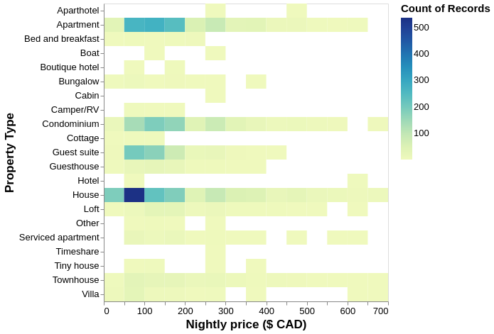

Figure 3: Number of properties by price and property type

Figure 3: Number of properties by price (CAD) and property type

Other than houses, condos and apartments, other categories have very sparse data, especially across price points. In particular, Aparthotel, Bed and breakfast, Boat, Boutique hotel, Cabin, Cottage, Hotel, Timeshare and Tinyhouse are problematic. The model we develop would be able to best predict on unseen house, apartment and condo properties since there is the most data to learn from across price points.

#### Preprocessing Our Data

Prior to fitting various machine learning models, we preprocessed our data to standardize scaling to improve the performance of models that rely on distance such as the KNN regressor. We also engineered the neighborhood feature, grouping neighborhoods into “Downtown”, “Vancouver West” and “Vancouver East” to reduce class imbalance and sparsity of data for various neighborhoods. Missing numeric values were replaced with median values for the feature; missing categorical values were denoted as “missing”.

### Building our model

The first step in identifying the most appropriate model was to evaluate four different machine learning models for accuracy and computational complexity. Mean squared error (MSE) was used as the accuracy metric since we are using regression techniques.

| Models | Train MSE | Validation MSE | Computation time (s) |
| --- | --- | --- | --- |
| Linear Regression | 70,542 | 72,763 | 0.0 |
| kNN Regressor | 62,294 | 85,796 | 0.7 |
| Support Vector Machine Regression | 77,553 | 78,726 | 2.0 |
| Random Forest Regressor | 18,037 | 132,636 | 5.2 |

Table 1: Baseline performance for four models

The linear regressor and support vector machine (SVM) regressor performed the best in terms of accuracy on the validation set. While the kNN regressor performed poorly, it has clearly overfit since hyperparameters had not been tuned yet. We will shortlist these three models for further analysis. As we can see, the random forest regressor was not only computationally intensive, but also performed poorly. Combined with the poor interpretability of random forest models, we have removed this model from our consideration set.

We tuned `n_neighbors` and `gamma` hyperparameters for our kNN and SVM regressors respectively. The following table shows our findings along with the results for our linear regressor.

| Models | Train MSE | Validation MSE | Computation time (s) |
| --- | --- | --- | --- |
| Linear Regression | 70,542 | 72,763 | 0.0 |
| Optimized kNN | 61,833 | 77,989 | 0.7 |
| Optimized SVM Regressor | 84,757 | 85,335 | 2.0 |

Table 2: Performance of optimized models

To our surprise, our linear regressor performed the best on both accuracy and computational complexity. Linear regression is also the most interpretable. As a result, our linear regressor was selected as the best model at this stage of our analysis.

### Evaluating our model: performance and limitations

To understand how our model performs on a variety of price ranges, we created the following residual plot showing the difference in predicted value compared to the actual price against actual prices.

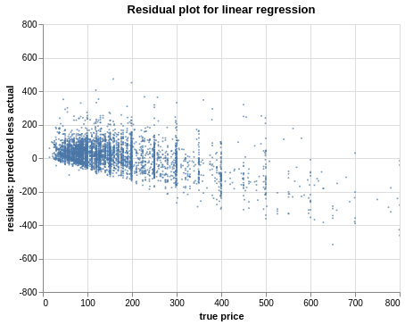

Figure 4: Residuals by true price for linear regression model

As we can see, our model tends to overestimate the price of AirBnB’s below $200/night and underestimate the price of AirBnB’s above $300/night. Since we fitted a linear model, this could indicate a non-linear relationship between our features and price. Right now, our model performs the best for properties that should be priced between $200 and $300/night, a limitation that should be taken account if a user were to use this model.

### Future directions

There are several ways to continue to improve our model performance that we list below:

1. **Further feature engineering:** We selected a subset of features from a large dataset to train our model on based on our knowledge of AirBnB. Interviewing AirBnB hosts and frequent guests could reveal other important features that impact pricing. For instance, interactions between features (e.g., a property that accommodates many people in downtown Vancouver would be valued compared to one in the suburbs) could significantly improve the performance of the model. Engineering our features to group property types that behave similarly but have few data points could also improve the performance of edge cases and imbalanced classes.
2. **Fitting more complex linear models:** Our results suggest a non-linear relationship between price and our features. We can explore improving model performance by assuming different model distributions that better reflect the long tail of higher priced properties.

Before our model is deployed for use, we also suggest pressure testing our model against a range of input values to identify the types of properties and bookings for which our model can make reliable predictions.

# References

Chandra, Rakesh Vidya, and Bala Subrahmanyam Varanasi. 2015. *Python Requests Essentials*. Packt Publishing Ltd.

de Jonge, Edwin. 2018. *Docopt: Command-Line Interface Specification Language*. https://CRAN.R-project.org/package=docopt.

Lang, Michel. 2017. “checkmate: Fast Argument Checks for Defensive R Programming.” *The R Journal* 9 (1): 437–45. https://journal.r-project.org/archive/2017/RJ-2017-028/index.html.

Lyttle, Ian. 2018. “Vegawidget: Introducing Altair.” https://vegawidget.rbind.io/posts/2018-05-20-introducing-altair/.

McKinney, Wes, and others. 2010. “Data Structures for Statistical Computing in Python.” In *Proceedings of the 9th Python in Science Conference*, 445:51–56. Austin, TX.

Oliphant, Travis E. 2006. *A Guide to Numpy*. Vol. 1. Trelgol Publishing USA.

Pedregosa, F., G. Varoquaux, A. Gramfort, V. Michel, B. Thirion, O. Grisel, M. Blondel, et al. 2011. “Scikit-Learn: Machine Learning in Python.” *Journal of Machine Learning Research* 12: 2825–30.

R Core Team. 2019. *R: A Language and Environment for Statistical Computing*. Vienna, Austria: R Foundation for Statistical Computing. https://www.R-project.org/.

Van Rossum, Guido, and Fred L. Drake. 2009. *Python 3 Reference Manual*. Scotts Valley, CA: CreateSpace.

Wickham, Hadley. 2011. “Testthat: Get Started with Testing.” *The R Journal* 3: 5–10. https://journal.r-project.org/archive/2011-1/RJournal_2011-1_Wickham.pdf.

———. 2017. *Tidyverse: Easily Install and Load the ’Tidyverse’*. https://CRAN.R-project.org/package=tidyverse.